# R Notebook

# Multiple Regression

```r
library(tidyverse)
library(skimr)
library(moderndive)
library(ISLR)
```

## One numerical and one categorical explanatory variable

### Interaction model

In the `evals` dataset, investigate the relationship between explanatory variables age (numerical) and gender (categorical), and score.

```r
evals_ch6 <- evals %>%
  select(ID, age, gender, score)

glimpse(evals_ch6)
```

```
Observations: 463
Variables: 4
$ ID     <int> 1, 2, 3, 4, 5, 6, 7, 8, 9, 10, 11, 12, 13, 14,…
$ age    <int> 36, 36, 36, 36, 59, 59, 59, 51, 51, 40, 40, 40…
$ gender <fct> female, female, female, female, male, male, ma…
$ score  <dbl> 4.7, 4.1, 3.9, 4.8, 4.6, 4.3, 2.8, 4.1, 3.4, 4…
```

[output not shown]

```r
evals_ch6 %>% select(age, gender, score) %>% skim()
```

```
── Data Summary ────────────────────────
                           Values
Name                       Piped data
Number of rows             463
Number of columns          3
_______________________
Column type frequency:
  factor                   1
  numeric                  2
________________________
Group variables            None

── Variable type: factor ──────────────────────────────────────────────────────────────────────────────────────────────────────────────────
  skim_variable n_missing complete_rate ordered n_unique top_counts
1 gender                0             1 FALSE          2 mal: 268, fem: 195

── Variable type: numeric ─────────────────────────────────────────────────────────────────────────────────────────────────────────────────
  skim_variable n_missing complete_rate  mean    sd    p0   p25   p50   p75  p100 hist
1 age                   0             1 48.4  9.80   29    42    48    57      73 ▅▆▇▆▁
2 score                 0             1  4.17 0.544   2.3   3.8   4.3   4.6     5 ▁▁▅▇▇
```

```r
evals_ch6 %>%
  summarise(r = cor(age, score))
```

| r |
| --- |
| -0.107032 |

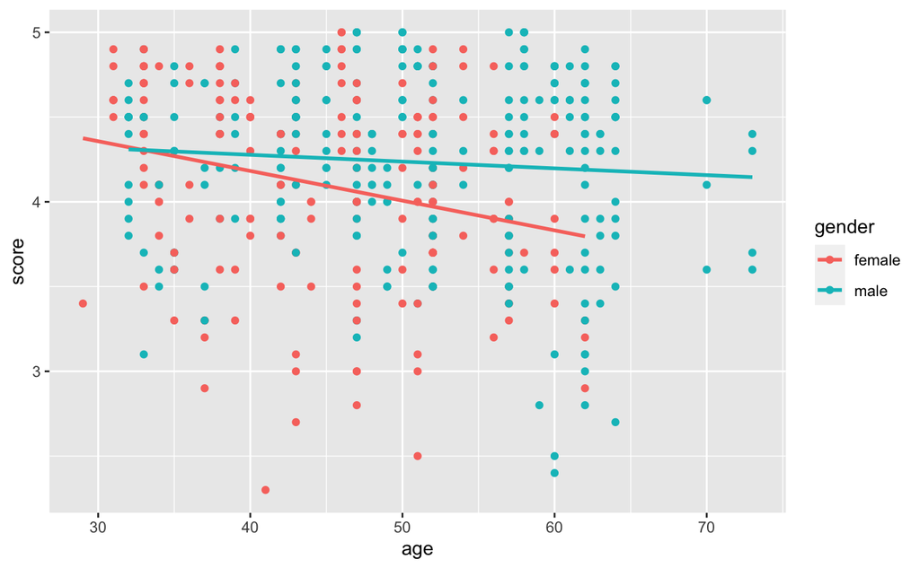

```r
evals_ch6 %>%
  ggplot(aes(x = age, y = score, color = gender)) +
    geom_point() +
    geom_smooth(method = 'lm', se = FALSE)
```

```r
library(broom)
score_model_interaction <- lm(score ~ age * gender, data = evals_ch6)
tidy(score_model_interaction)
```

| term | estimate | std.error | statistic | p.value |
| --- | --- | --- | --- | --- |
| (Intercept) | 4.88298909 | 0.205210483 | 23.795027 | 4.018554e-82 |
| age | -0.01752336 | 0.004471954 | -3.918501 | 1.026671e-04 |
| gendermale | -0.44604355 | 0.265406519 | -1.680605 | 9.351998e-02 |
| age:gendermale | 0.01353061 | 0.005530825 | 2.446399 | 1.480337e-02 |

In an interaction model like this, the reqgression lines
$$\hat{y} = \widehat{score} = b_0 + b_\textrm{age} \cdot \textrm{age} + b_\textrm{male} \cdot 1_\textrm{is male}(x) + b_\textrm{age,male} \cdot \textrm{age} \cdot 1_\textrm{is male}(x)$$
As was the case with the model using a single categorical explanatory variable, the indicator term $1_\textrm{is male}(x)$ zeroes out if the record is not male. The interaction effect, $b_\textrm{age,male}$ is `age:gendermale` from the regression table. This term indicates the extent to which one variable (`age`) depends on another (`gender`)

Thus the equation for the female line is:

$$\hat{y} = \widehat{score} = 4.883 - .018 \cdot age$$
Whereas for males it’s:
$$\hat{y} = \widehat{score} = (4.883 - .446) + (-.018 + 0.014) \cdot age \\
= 4.437 - 0.004 \cdot age$$

### Parallel slopes

In an interaction model, the explanatory variables can behave differently across groups. In the `age * gender` model, the `age` penalty for men was significantly lower for men than for women.

In a parallel slopes model, only the intercept varies. Rather than `age * gender`, the model is `age + gender`.

```r
score_model_parallel_slopes <- lm(score ~ age + gender, data = evals_ch6)
tidy(score_model_parallel_slopes)
```

| term | estimate | std.error | statistic | p.value |
| --- | --- | --- | --- | --- |
| (Intercept) | 4.48411621 | 0.125283582 | 35.791731 | 4.835503e-135 |
| age | -0.00867766 | 0.002645634 | -3.279992 | 1.116933e-03 |
| gendermale | 0.19057099 | 0.052469165 | 3.632057 | 3.128038e-04 |

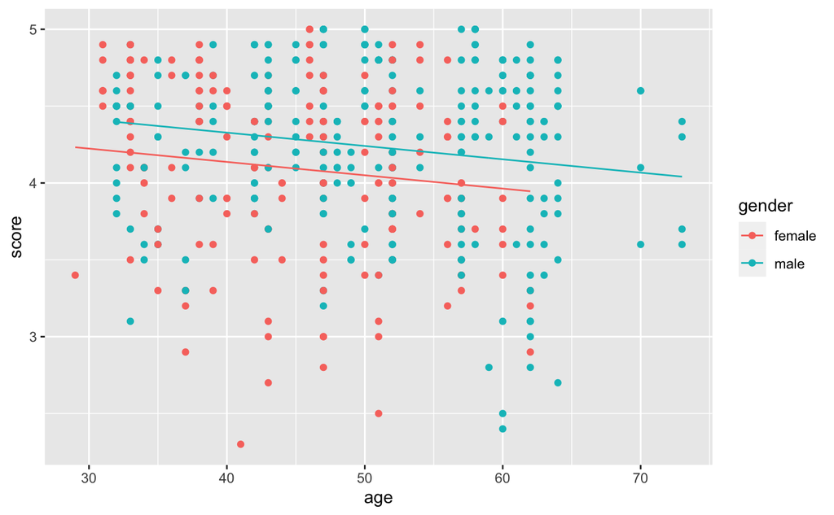

```r
score_model_parallel_slopes %>%
  augment() %>%
  ggplot(aes(x = age, y = score, color = gender)) +
    geom_point() +
    geom_line(aes(y = .fitted))
```

### Residuals

```r
score_model_interaction %>%
  augment() %>%
  select(score, age, gender, .fitted, .resid)
```

| score | age | gender | .fitted | .resid |
| --- | --- | --- | --- | --- |
| 4.7 | 36 | female | 4.252148 | 0.447851740 |
| 4.1 | 36 | female | 4.252148 | -0.152148260 |
| 3.9 | 36 | female | 4.252148 | -0.352148260 |
| 4.8 | 36 | female | 4.252148 | 0.547851740 |
| 4.6 | 59 | male | 4.201373 | 0.398626729 |
| 4.3 | 59 | male | 4.201373 | 0.098626729 |
| 2.8 | 59 | male | 4.201373 | -1.401373271 |
| 4.1 | 51 | male | 4.233315 | -0.133315272 |
| 3.4 | 51 | male | 4.233315 | -0.833315272 |
| 4.5 | 40 | female | 4.182055 | 0.317945165 |

[output cut: 453 more lines]

```r
score_model_parallel_slopes %>%
  augment() %>%
  select(score, age, gender, .fitted, .resid)
```

| score | age | gender | .fitted | .resid |
| --- | --- | --- | --- | --- |
| 4.7 | 36 | female | 4.171720 | 0.528279535 |
| 4.1 | 36 | female | 4.171720 | -0.071720465 |
| 3.9 | 36 | female | 4.171720 | -0.271720465 |
| 4.8 | 36 | female | 4.171720 | 0.628279535 |
| 4.6 | 59 | male | 4.162705 | 0.437294714 |
| 4.3 | 59 | male | 4.162705 | 0.137294714 |
| 2.8 | 59 | male | 4.162705 | -1.362705286 |
| 4.1 | 51 | male | 4.232127 | -0.132126564 |
| 3.4 | 51 | male | 4.232127 | -0.832126564 |
| 4.5 | 40 | female | 4.137010 | 0.362990174 |

[output cut: 453 more lines]

## Two Numerical Explanatory Variables

Model debt ($y$) as a factor of credit limit ($x_1$) and income ($x_2$).

```r
credit_ch6 <- Credit %>%
  as_tibble() %>%
    select(ID, debt = Balance, credit_limit = Limit,
           income = Income, credit_rating = Rating, age = Age)

glimpse(credit_ch6)
```

```
Observations: 400
Variables: 6
$ ID            <int> 1, 2, 3, 4, 5, 6, 7, 8, 9, 10, 11, 12, 13, 14, 15, 16, 17, 18, 19, 20, 21, 22, 23, 24, 25, 26, 27, 28, 29, 30, 31…
$ debt          <int> 333, 903, 580, 964, 331, 1151, 203, 872, 279, 1350, 1407, 0, 204, 1081, 148, 0, 0, 368, 891, 1048, 89, 968, 0, 41…
$ credit_limit  <int> 3606, 6645, 7075, 9504, 4897, 8047, 3388, 7114, 3300, 6819, 8117, 1311, 5308, 6922, 3291, 2525, 3714, 4378, 6384,…
$ income        <dbl> 14.891, 106.025, 104.593, 148.924, 55.882, 80.180, 20.996, 71.408, 15.125, 71.061, 63.095, 15.045, 80.616, 43.682…
$ credit_rating <int> 283, 483, 514, 681, 357, 569, 259, 512, 266, 491, 589, 138, 394, 511, 269, 200, 286, 339, 448, 479, 235, 458, 213…
$ age           <int> 34, 82, 71, 36, 68, 77, 37, 87, 66, 41, 30, 64, 57, 49, 75, 57, 73, 69, 28, 44, 63, 72, 61, 48, 57, 25, 44, 44, 4…
```

```r
credit_ch6 %>% sample_n(6)
```

| ID | debt | credit_limit | income | credit_rating | age |
| --- | --- | --- | --- | --- | --- |
| 306 | 0 | 1924 | 24.460 | 165 | 50 |
| 260 | 1092 | 6196 | 33.657 | 450 | 55 |
| 201 | 829 | 5343 | 23.949 | 383 | 40 |
| 140 | 1597 | 10384 | 107.841 | 728 | 87 |
| 175 | 1573 | 10673 | 121.834 | 750 | 54 |
| 77 | 532 | 3293 | 30.622 | 251 | 68 |

```r
credit_ch6 %>% select(debt, credit_limit, age) %>% skim()
```

```
── Data Summary ────────────────────────
                           Values
Name                       Piped data
Number of rows             400
Number of columns          3
_______________________
Column type frequency:
  numeric                  3
________________________
Group variables            None

── Variable type: numeric ────────────────────────────────────────────────────────────────────────────────────────────────────────────────
  skim_variable n_missing complete_rate   mean     sd    p0    p25   p50   p75  p100 hist
1 debt                  0             1  520.   460.      0   68.8  460.  863   1999 ▇▅▃▂▁
2 credit_limit          0             1 4736.  2308.    855 3088   4622. 5873. 13913 ▆▇▃▁▁
3 age                   0             1   55.7   17.2    23   41.8   56    70     98 ▆▇▇▇▁
```

```r
credit_ch6 %>%
  summarise(r_debt_credit_limit = cor(debt, credit_limit),
            r_debt_age = cor(debt, age))
```

| r_debt_credit_limit | r_debt_age |
| --- | --- |
| 0.8616973 | 0.001835119 |

```r
credit_ch6 %>%
  select(debt, credit_limit, age) %>%
  cor()
```

```
                    debt credit_limit         age
debt         1.000000000    0.8616973 0.001835119
credit_limit 0.861697267    1.0000000 0.100887922
age          0.001835119    0.1008879 1.000000000
```

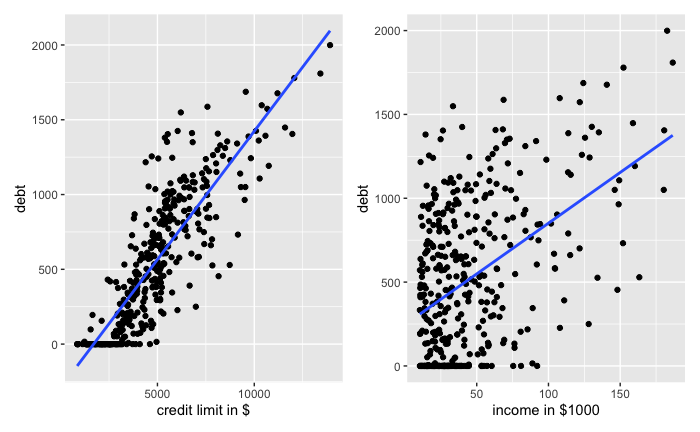

```r
library(patchwork)
credit_ch6 %>%
  ggplot(aes(x = credit_limit, y = debt)) +
    geom_point() +
    geom_smooth(method = 'lm', se = FALSE) +
    xlab('credit limit in $') -> p1

credit_ch6 %>%
  ggplot(aes(x = income, y = debt)) +
    geom_point() +
    geom_smooth(method = 'lm', se = FALSE) +
    xlab('income in $1000') -> p2

p1 + p2
```

```r
debt_model <- lm(debt ~ credit_limit + income, data = credit_ch6)
tidy(debt_model)
```

| term | estimate | std.error | statistic | p.value |
| --- | --- | --- | --- | --- |
| (Intercept) | -385.1792604 | 19.464801525 | -19.78850 | 3.878764e-61 |
| credit_limit | 0.2643216 | 0.005879729 | 44.95471 | 7.717386e-158 |
| income | -7.6633230 | 0.385072058 | -19.90101 | 1.260933e-61 |

This plots separately show the relationships between credit limit and debt and between income and debt, but in order to show the relationship between all 3, a 3D plot is needed, and the regression surface is a plane rather than a line.

### Debt, Credit Rating and Age

```r
credit_ch6 %>%
  select(debt, credit_rating, age) %>%
  skim()
```

```
── Data Summary ────────────────────────
                           Values
Name                       Piped data
Number of rows             400
Number of columns          3
_______________________
Column type frequency:
  numeric                  3
________________________
Group variables            None

── Variable type: numeric ────────────────────────────────────────────────────────────────────────────────────────────────────────────────
  skim_variable n_missing complete_rate  mean    sd    p0   p25   p50   p75  p100 hist
1 debt                  0             1 520.  460.      0  68.8  460.  863   1999 ▇▅▃▂▁
2 credit_rating         0             1 355.  155.     93 247.   344   437.   982 ▆▇▃▁▁
3 age                   0             1  55.7  17.2    23  41.8   56    70     98 ▆▇▇▇▁
```

```r
credit_ch6 %>%
  summarise(r_debt_credit_rating = cor(debt, credit_rating), r_debt_age = cor(debt, age))
```

| r_debt_credit_rating | r_debt_age |
| --- | --- |
| 0.8636252 | 0.001835119 |

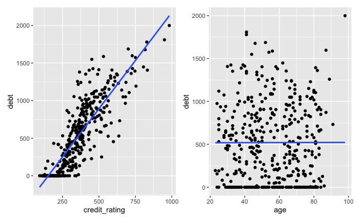

```r
p1 <- credit_ch6 %>%
  ggplot(aes(x = credit_rating, y = debt)) +
    geom_point() +
    geom_smooth(method = "lm", se = FALSE)
p2 <- credit_ch6 %>%
  ggplot(aes(x = age, y = debt)) +
    geom_point() +
    geom_smooth(method = "lm", se = FALSE)

p1 + p2
```

### Regression Plane

```r
debt_model <- lm(debt ~ credit_limit + income, data = credit_ch6)
tidy(debt_model)
```

| term | estimate | std.error | statistic | p.value |
| --- | --- | --- | --- | --- |
| (Intercept) | -385.1792604 | 19.464801525 | -19.78850 | 3.878764e-61 |
| credit_limit | 0.2643216 | 0.005879729 | 44.95471 | 7.717386e-158 |
| income | -7.6633230 | 0.385072058 | -19.90101 | 1.260933e-61 |

#### Regression Plane with Debt, Credit Rating and Age

```r
debt_credit_age_model <- lm(debt ~ credit_rating + age, data = credit_ch6)
tidy(debt_credit_age_model)
```

| term | estimate | std.error | statistic | p.value |
| --- | --- | --- | --- | --- |
| (Intercept) | -269.581100 | 44.80616328 | -6.016608 | 4.049437e-09 |
| credit_rating | 2.593278 | 0.07443365 | 34.840132 | 8.387877e-123 |
| age | -2.350779 | 0.66764122 | -3.521022 | 4.797866e-04 |